# Health Care Management Exploration v2

Faizan Khalid Mohsin

February 13, 2018

#### Use the data for five countries (Canada, US, UK plus 2 others you choose) to compare trends and the current situation in these health systems. Please prepare a report using tables/charts.

#### On trend charts, use 1985 to the latest year available (except where noted), but label in five year increments (85, 90 etc, 2000, 05, 10, 15 or whatever the latest is; otherwise the x axis will be unreadable). In the most recent charts, indicate the most recent data date (e.g. 2016, except where noted) and using notes (superscript numbers, indicate the other years.) Line graphs work better for trends over time. Bar graphs are typically used when comparing variables by different groups (e.g. countries).

##### Questions:

1. Demographics:
   1. Figure. Life expectancy at birth, for all. Trend (for this go back to 1970)

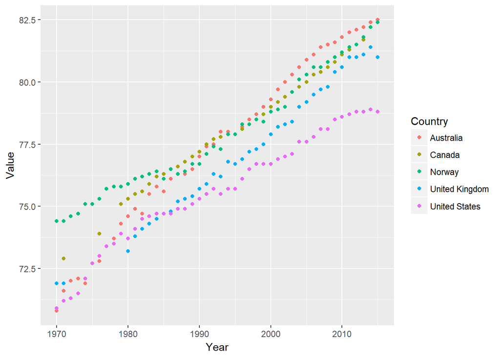

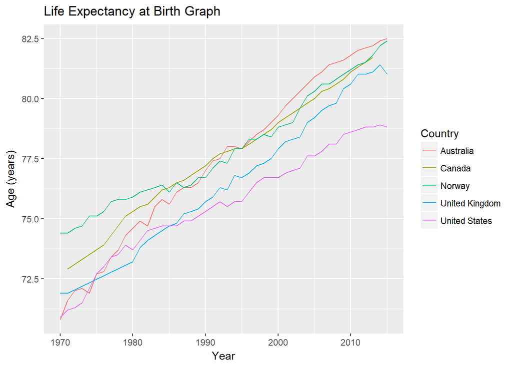

1. Demographics:
   2. Figure. Share of population age 65 or more. Trend (go back to 1980)

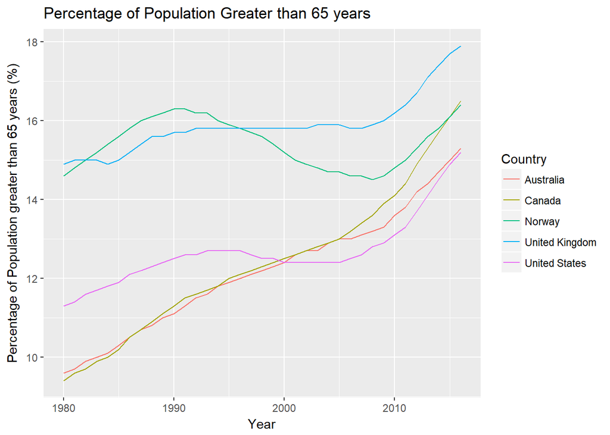

Life Expectancy at Birth by Country and Gender.

|  | Country | Females | Males | Total Population |
| --- | --- | --- | --- | --- |
| 1 | Australia | 84.5 | 80.4 | 82.5 |
| 4 | Norway | 84.2 | 80.5 | 82.4 |
| 7 | United Kingdom | 82.8 | 79.2 | 81.0 |
| 10 | United States | 81.2 | 76.3 | 78.8 |

Now we will present the data in the table as a graph.

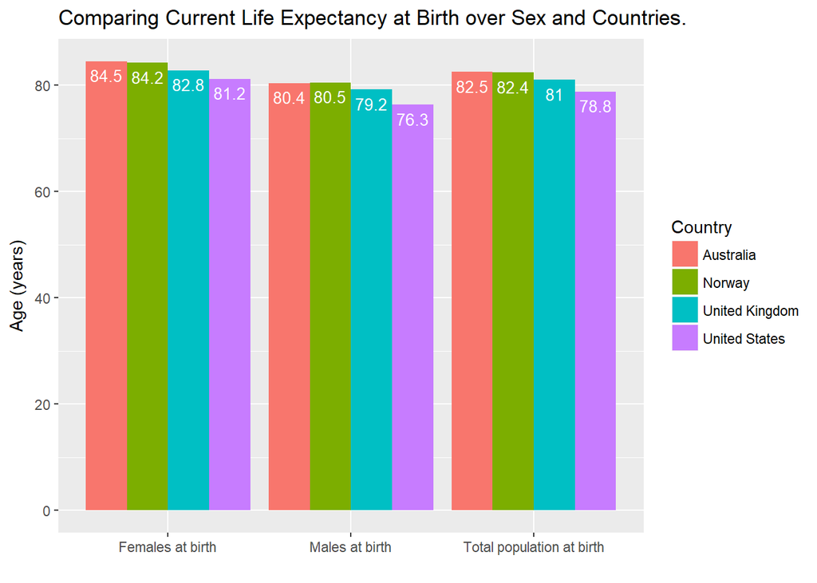

Percentage of Population aged 15+ Who are Daily Smokers for the Year 2013

| Country | % of population aged 15+ who are daily smokers |
| --- | --- |
| Australia | 13.0 |
| Canada | 14.9 |
| Norway | 15.0 |
| United Kingdom | 19.0 |
| United States | 13.7 |

2. Expenditure & finance:
   1. Figure. Total health expenditure as share of GDP (trend, from 1985).

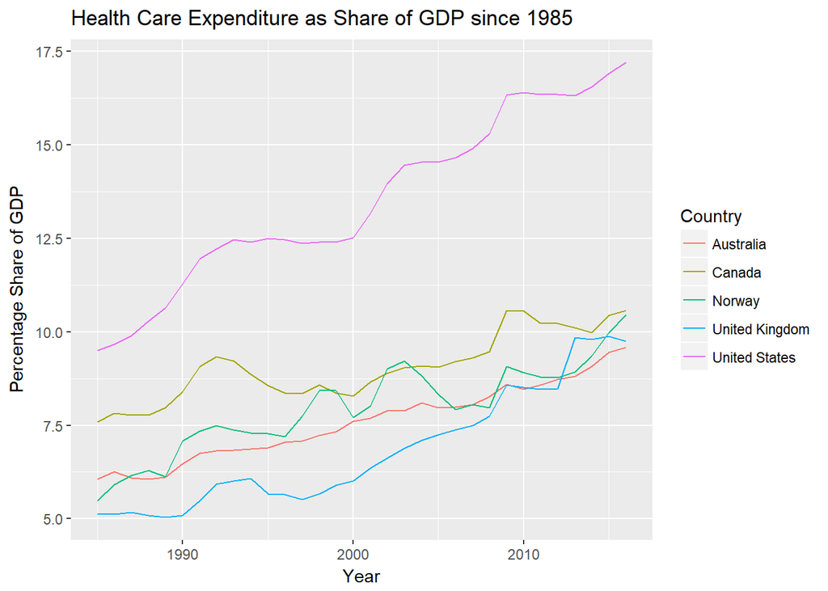

```
  ii. Figure. Bar graph. Total health expenditure as share of GDP, current situation.
```

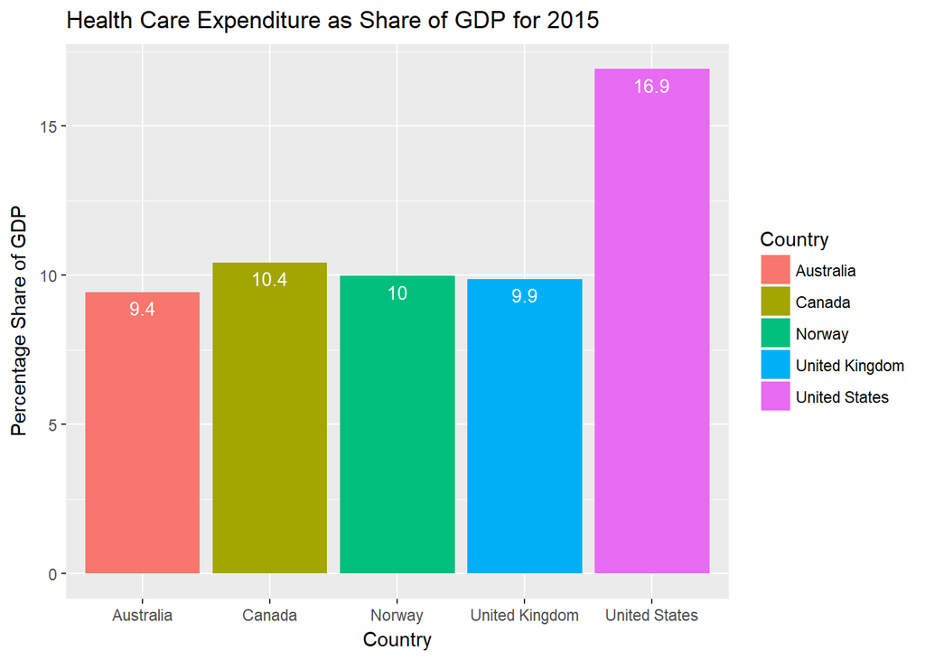

[output not shown]

```r
# Import and clean data, Note we are using total pharmaceutical sales as "Spending on drugs"
# rawdata = read.csv("")


# Creating a bar graph
#ggplot(data=HealthCare_current_data, aes(x=Country, y=Value, fill=Country)) + geom_bar(stat="identity") + geom_text(aes(label=ValueR), vjust=1.6, color="white", size=3.5) + ggtitle("Health Care Expenditure as Share of GDP for 2015")+ labs(y = "Percentage Share of GDP")
```

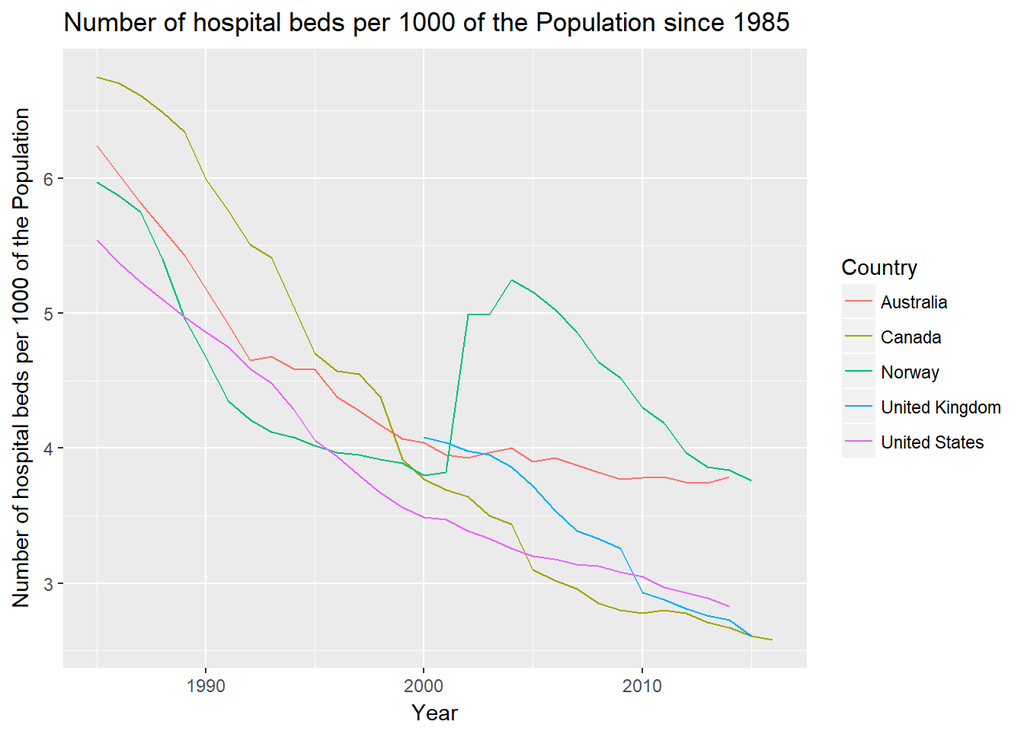

[output not shown]

```r
# Import and clean the data:
#rawdata= read.csv()
```

(You can try to put ii and iii on the same graph. If you can’t do it, don’t worry because it is complicated). Make sure the figures are legible, the Y axis labelled (you don’t need to label “year” or “country” on the X axis, the labels for the years and countries are sufficient.). Also sure the same colours/patterns are used for each country for each figure. Tables can be as in the examples. Every table requires a source (E.g. Source: OECD, 2017), and the reference at the end of the assignment.